# nestedcv

Myles Lewis, Athina Spiliopoulou, Katriona Goldmann

# Introduction

The motivation for this package is to provide functions which help with the development and tuning of machine learning models in biomedical data where the sample size is frequently limited, but the number of predictors may be significantly larger (P >> n). While most machine learning pipelines involve splitting data into training and testing cohorts, typically 2/3 and 1/3 respectively, medical datasets may be too small for this, and so determination of accuracy in the left-out test set suffers because the test set is small. Nested cross-validation (CV) provides a way to get round this, by maximising use of the whole dataset for testing overall accuracy, while maintaining the split between training and testing.

In addition typical biomedical datasets often have many 10,000s of possible predictors, so filtering of predictors is commonly needed. However, it has been demonstrated that filtering on the whole dataset creates a bias when determining accuracy of models (Vabalas et al, 2019). Feature selection of predictors should be considered an integral part of a model, with feature selection performed only on training data. Then the selected features and accompanying model can be tested on hold-out test data without bias. Thus, it is recommended that any filtering of predictors is performed within the CV loops, to prevent test data information leakage.

This package enables nested cross-validation (CV) to be performed using the commonly used `glmnet` package, which fits elastic net regression models, and the `caret` package, which is a general framework for fitting a large number of machine learning models. In addition, `nestedcv` adds functionality to enable cross-validation of the elastic net alpha parameter when fitting `glmnet` models.

`nestedcv` partitions the dataset into outer and inner folds (default 10 x 10 folds). The inner fold CV, (default is 10-fold), is used to tune optimal hyperparameters for models. Then the model is fitted on the whole inner fold and tested on the left-out data from the outer fold. This is repeated across all outer folds (default 10 outer folds), and the unseen test predictions from the outer folds are compared against the true results for the outer test folds and the results concatenated, to give measures of accuracy (e.g. AUC and accuracy for classification, or RMSE for regression) across the whole dataset.

A final round of CV is performed on the whole dataset to determine hyperparameters to fit the final model to the whole data, which can be used for prediction with external data.

### Variable selection

While some models such as `glmnet` allow for sparsity and have variable selection built-in, many models fail to fit when given massive numbers of predictors, or perform poorly due to overfitting without variable selection. In addition, in medicine one of the goals of predictive modelling is commonly the development of diagnostic or biomarker tests, for which reducing the number of predictors is typically a practical necessity.

Several filter functions (t-test, Wilcoxon test, anova, Pearson/Spearman correlation, random forest variable importance, and ReliefF from the `CORElearn` package) for feature selection are provided, and can be embedded within the outer loop of the nested CV.

# Installation

```r
install.packages("nestedcv")
library(nestedcv)
```

# Examples

### Importance of nested CV

The following simulated example demonstrates the bias intrinsic to datasets where *P* >> *n* when applying filtering of predictors to the whole dataset rather than to training folds.

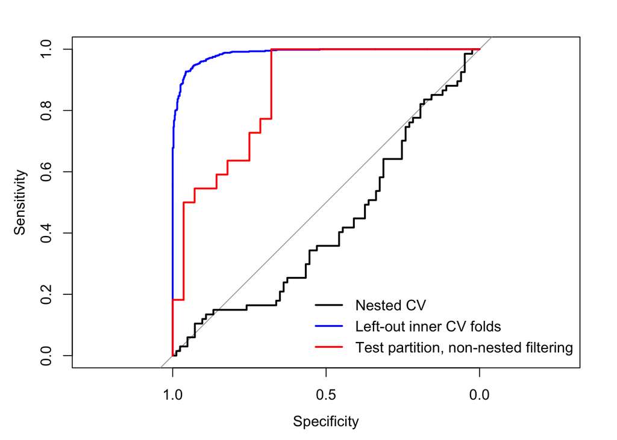

```r
## Example binary classification problem with P >> n
x <- matrix(rnorm(150 * 2e+04), 150, 2e+04)  # predictors
y <- factor(rbinom(150, 1, 0.5))  # binary response

## Partition data into 2/3 training set, 1/3 test set
trainSet <- caret::createDataPartition(y, p = 0.66, list = FALSE)

## t-test filter using whole test set
filt <- ttest_filter(y, x, nfilter = 100)
filx <- x[, filt]

## Train glmnet on training set only using filtered predictor matrix
library(glmnet)
## Loading required package: Matrix
## Loaded glmnet 4.1-10
fit <- cv.glmnet(filx[trainSet, ], y[trainSet], family = "binomial")

## Predict response on test set
predy <- predict(fit, newx = filx[-trainSet, ], s = "lambda.min", type = "class")
predy <- as.vector(predy)
predyp <- predict(fit, newx = filx[-trainSet, ], s = "lambda.min", type = "response")
predyp <- as.vector(predyp)
output <- data.frame(testy = y[-trainSet], predy = predy, predyp = predyp)

## Results on test set
## shows bias since univariate filtering was applied to whole dataset
predSummary(output)
##          Reference
## Predicted  0  1
##         0 20  5
##         1  8 17
##
##               AUC            Accuracy   Balanced accuracy
##            0.8620              0.7400              0.7435

## Nested CV
fit2 <- nestcv.glmnet(y, x, family = "binomial", alphaSet = 7:10 / 10,
                      filterFUN = ttest_filter,
                      filter_options = list(nfilter = 100))
fit2
## Nested cross-validation with glmnet
## Filter:  ttest_filter
##
## Final parameters:
##    lambda      alpha
## 0.0005779  0.7000000
##
## Final coefficients:
## (Intercept)      V17189       V4653      V10268      V10334      V10625
##   -0.731390    1.143523    0.773866    0.773178    0.754825    0.721814
##       V7655       V2795      V11848      V14537       V4804       V8776
##   -0.666299    0.602987   -0.589314    0.578985   -0.570714    0.558527
##      V17923       V5488      V13710      V16607      V18743       V3640
##   -0.548157   -0.544366   -0.531189    0.529424   -0.529168    0.527939
##      V14970       V7070      V17702       V9376      V16466      V14527
##    0.516625   -0.513053    0.482439    0.480952   -0.466487    0.460409
##      V18809       V1735      V18066       V3028       V2372       V4329
##   -0.457455   -0.445065   -0.425353    0.423534    0.412796    0.399092
##      V10855       V4920       V8442      V18845       V1223      V12688
##    0.377454    0.373419    0.360024   -0.351765   -0.346290   -0.342559
##       V5543       V5074       V9300      V15515       V4482      V18361
##    0.341095   -0.336059   -0.320679    0.314187   -0.305739   -0.299763
##       V7227       V5042       V3364      V17896       V9564      V12042
##   -0.299409   -0.296663    0.288349   -0.286229    0.286006   -0.283704
##      V12044      V18477      V17460       V6563      V19501       V1471
##    0.278959   -0.278137   -0.277323    0.275041   -0.260382   -0.257573
##       V1330       V1130       V9240       V3012       V9907      V14491
##    0.255933   -0.254288   -0.254264    0.252646   -0.238996    0.230311
##      V10036      V12346       V1149       V1806      V13246        V468
##    0.225273   -0.213122   -0.211483    0.192064   -0.187454   -0.163786
##       V6704        V632      V18465      V11968       V4028        V871
##   -0.162893   -0.160443    0.159746    0.157393    0.145637    0.138109
##       V9259       V2627      V15298        V384       V5828      V19481
##    0.137508    0.136249   -0.134969    0.125350    0.124884   -0.121225
##       V3724        V994      V16951       V2275      V12495       V7113
##   -0.095243    0.091909    0.049475   -0.041507   -0.036363    0.034242
##      V17145      V17550       V9609      V16798       V7551      V13579
##   -0.030977    0.023864   -0.021984   -0.009174    0.006188    0.005883
##
## Result:
##          Reference
## Predicted  0  1
##         0 46 47
##         1 37 20
##
##               AUC            Accuracy   Balanced accuracy
##            0.4267              0.4400              0.4264

testroc <- pROC::roc(output$testy, output$predyp, direction = "<", quiet = TRUE)
inroc <- innercv_roc(fit2)
plot(fit2$roc)
lines(inroc, col = 'blue')
lines(testroc, col = 'red')
legend('bottomright', legend = c("Nested CV", "Left-out inner CV folds",
                                 "Test partition, non-nested filtering"),
       col = c("black", "blue", "red"), lty = 1, lwd = 2, bty = "n")
```

In this example the dataset is pure noise. Filtering of predictors on the whole dataset is a source of leakage of information about the test set, leading to substantially overoptimistic performance on the test set as measured by ROC AUC.

Figures A & B below show two commonly used, but biased methods in which cross-validation is used to fit models, but the result is a biased estimate of model performance. In scheme A, there is no hold-out test set at all, so there are two sources of bias/ data leakage: first, the filtering on the whole dataset, and second, the use of left-out CV folds for measuring performance. Left-out CV folds are known to lead to biased estimates of performance as the tuning parameters are ‘learnt’ from optimising the result on the left-out CV fold.

In scheme B, the CV is used to tune parameters and a hold-out set is used to measure performance, but information leakage occurs when filtering is applied to the *whole* dataset. Unfortunately this is commonly observed in many studies which apply differential expression analysis on the whole dataset to select predictors which are then passed to machine learning algorithms.

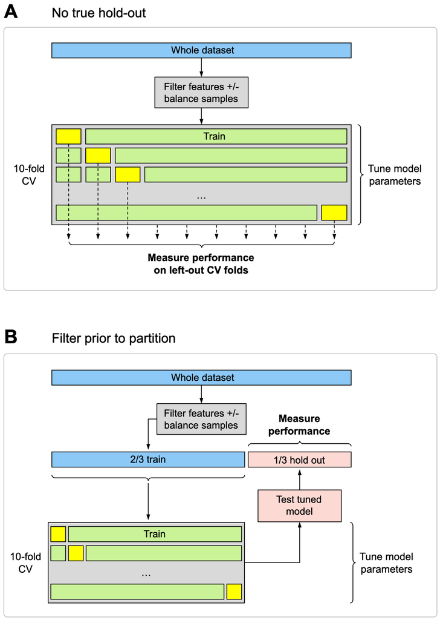

Figures C & D below show two valid methods for fitting a model with CV for tuning parameters as well as unbiased estimates of model performance. Figure C is a traditional hold-out test set, with the dataset partitioned 2/3 training, 1/3 test. Notably the critical difference between scheme B above, is that the filtering is only done on the training set and not on the whole dataset.

Figure D shows the scheme for fully nested cross-validation. Note that filtering is applied to each outer CV training fold. The key advantage of nested CV is that outer CV test folds are collated to give an improved estimate of performance compared to scheme C since the numbers for total testing are larger.

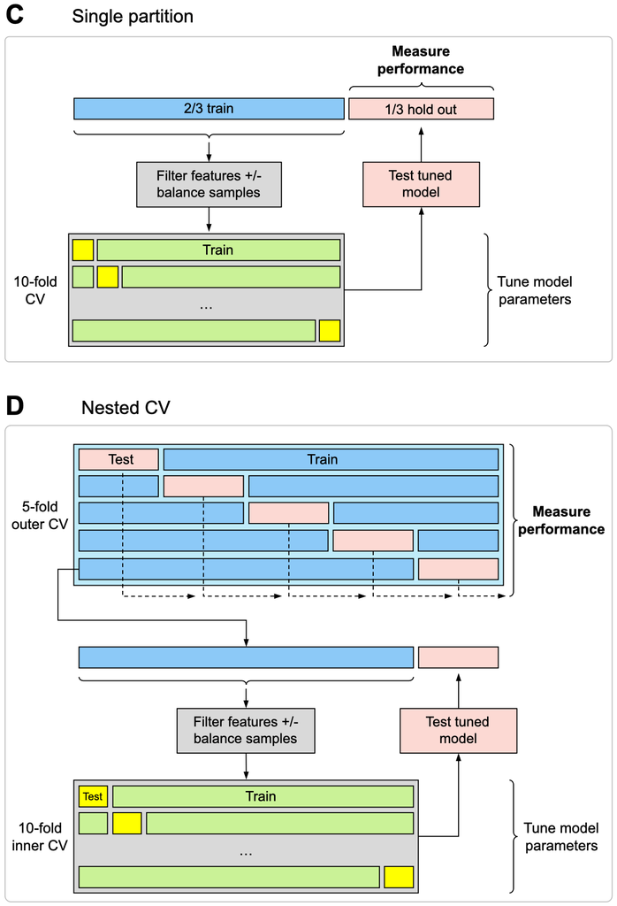

# Nested CV with glmnet

In the real life example below, RNA-Sequencing gene expression data from synovial biopsies from patients with rheumatoid arthritis in the R4RA randomised clinical trial (Humby et al, 2021) is used to predict clinical response to the biologic drug rituximab. Treatment response is determined by a clinical measure, namely Clinical Disease Activity Index (CDAI) 50% response, which has a binary outcome: treatment success or failure (response or non-response). This dataset contains gene expression on over 50,000 genes in arthritic synovial tissue from 133 individuals, who were randomised to two drugs (rituximab and tocilizumab). First, we remove genes of low expression using a median cut-off (this still leaves >16,000 genes), and we subset the dataset to the rituximab treated individuals (n=68).

```r
# Raw RNA-Seq data for this example is located at:
# https://www.ebi.ac.uk/arrayexpress/experiments/E-MTAB-11611/

# set up data
load("/../R4RA_270821.RData")

index <- r4ra.meta$Outliers_Detected_On_PCA != "outlier" & r4ra.meta$Visit == 3 &
          !is.na(r4ra.meta$Visit)
metadata <- r4ra.meta[index, ]
dim(metadata)  # 133 individuals

medians <- Rfast::rowMedians(as.matrix(r4ra.vst))
data <- t(as.matrix(r4ra.vst))
# remove low expressed genes
data <- data[index, medians > 6]
dim(data)  # 16254 genes

# Rituximab cohort only
yrtx <- metadata$CDAI.response.status.V7[metadata$Randomised.medication == "Rituximab"]
yrtx <- factor(yrtx)
data.rtx <- data[metadata$Randomised.medication == "Rituximab", ]

# no filter
res.rtx <- nestcv.glmnet(y = yrtx, x = data.rtx,
                         family = "binomial", cv.cores = 8,
                         alphaSet = seq(0.7, 1, 0.05))
res.rtx
```

[output not shown]

Use `summary()` to see full information from the nested model fitting. `coef()` can be used to show the coefficients of the final fitted model. For comparison, performance metrics from the left-out inner CV test folds can be viewed using `innercv_summary()`. Performance metrics on the outer training folds can be viewed with `train_summary()`, provided the argument `outer_train_predict` was set to `TRUE` in the original call to either `nestcv.glmnet()`, `nestcv.train()` or `outercv()`.

Filters can be used by setting the `filterFUN` argument. Options for the filter function are passed as a list through `filter_options`.

```r
# t-test filter
res.rtx <- nestcv.glmnet(y = yrtx, x = data.rtx, filterFUN = ttest_filter,
                         filter_options = list(nfilter = 300, p_cutoff = NULL),
                         family = "binomial", cv.cores = 8,
                         alphaSet = seq(0.7, 1, 0.05))
summary(res.rtx)
```

Output from the nested CV with glmnet can be plotted to show how deviance is affected by alpha and lambda.

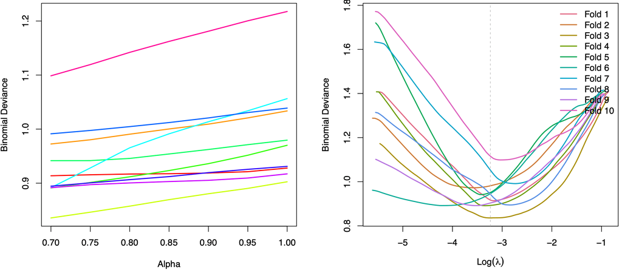

```r
plot_alphas(res.rtx)
plot_lambdas(res.rtx)
```

The tuning of alpha for each outer fold can be plotted.

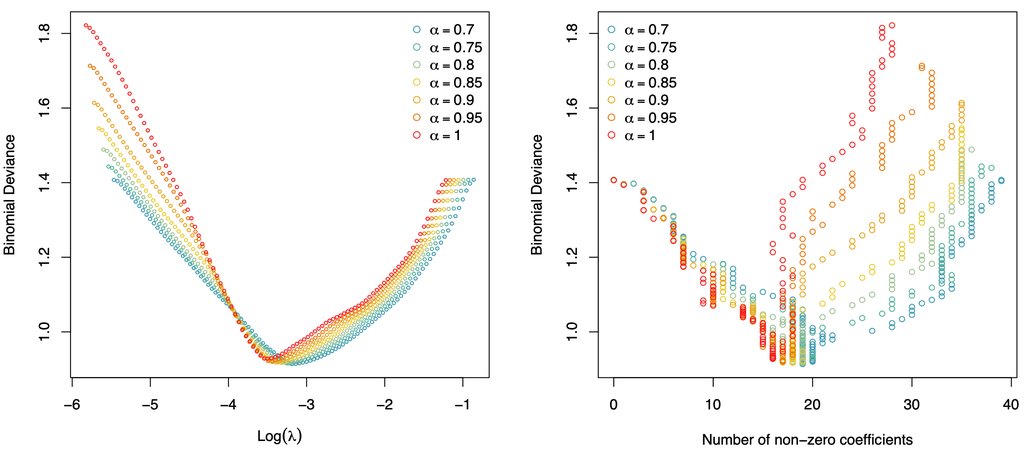

```r
# Fold 1 line plot
plot(res.rtx$outer_result[[1]]$cvafit)

# Scatter plot
plot(res.rtx$outer_result[[1]]$cvafit, type = 'p')

# Number of non-zero coefficients
plot(res.rtx$outer_result[[1]]$cvafit, xaxis = 'nvar')
```

ROC curves from left-out folds from both outer and inner CV can be plotted. Note that the AUC based on the left-out outer folds is the unbiased estimate of accuracy, while the left-out inner folds demonstrate bias due to the optimisation of the model’s hyperparameters on the inner fold data.

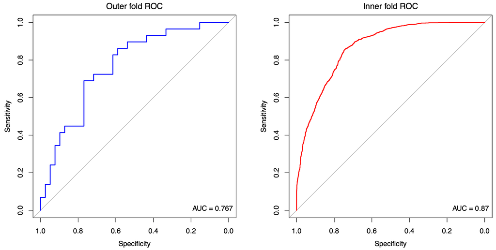

```r
# Outer CV ROC
plot(res.rtx$roc, main = "Outer fold ROC", font.main = 1, col = 'blue')
legend("bottomright", legend = paste0("AUC = ", signif(pROC::auc(res.rtx$roc), 3)), bty = 'n')

# Inner CV ROC
rtx.inroc <- innercv_roc(res.rtx)
plot(rtx.inroc, main = "Inner fold ROC", font.main = 1, col = 'red')
legend("bottomright", legend = paste0("AUC = ", signif(pROC::auc(rtx.inroc), 3)), bty = 'n')
```

Leave-one-out cross-validation (LOOCV) can be performed on the outer folds.

```r
# Outer LOOCV
res.rtx <- nestcv.glmnet(y = yrtx, x = data.rtx, min_1se = 0, filterFUN = ttest_filter,
                         filter_options = list(nfilter = 300, p_cutoff = NULL),
                         outer_method = "LOOCV",
                         family = "binomial", cv.cores = 8,
                         alphaSet = seq(0.7, 1, 0.05))
summary(res.rtx)
```

### One-hot encoding (dummy variables)

`glmnet` and some caret models (e.g. SVM) can only accept a numeric matrix of predictors. Dataframes of predictors with factors or character variables can be converted to a matrix using one-hot encoding to create dummy variables using the function `one_hot()`. For `nestcv.glmnet` models, `one_hot()` should be used with the argument `all_levels = FALSE` to avoid the predictor matrix not being full rank.

# Filters

Multiple filters for variable reduction are available including:

| `ttest_filter` | t-test |
| --- | --- |
| `wilcoxon_filter` | Wilcoxon (Mann-Whitney) test |
| `anova_filter` | one-way ANOVA |
| `correl_filter` | Pearson or Spearman correlation for regression modelling |
| `lm_filter` | linear model with covariates |
| `rf_filter` | random forest variable importance using randomForest package |
| `ranger_filter` | random forest variable importance using ranger package |
| `relieff_filter` | ReliefF and other methods available via CORElearn |
| `glmnet_filter` | uses sparsity of elastic net regression using glmnet to restrict variables |
| `pls_filter` | partial least squares regression filter using pls package |
| `boruta_filter` | Boruta |
| `stat_filter` | A swiss army knife univariate statistical filter for mixed data with combined continuous & categorical data |

```r
# Random forest filter
res.rtx <- nestcv.glmnet(y = yrtx, x = data.rtx, min_1se = 0.5, filterFUN = rf_filter,
                         filter_options = list(nfilter = 300),
                         family = "binomial", cv.cores = 8,
                         alphaSet = seq(0.7, 1, 0.05))
summary(res.rtx)

# ReliefF algorithm filter
res.rtx <- nestcv.glmnet(y = yrtx, x = data.rtx, min_1se = 0, filterFUN = relieff_filter,
                         filter_options = list(nfilter = 300),
                         family = "binomial", cv.cores = 8,
                         alphaSet = seq(0.7, 1, 0.05))
summary(res.rtx)
```

Bootstrapped versions of the univariate filters are available [see `boot_ttest()`]. These use repeated random sampling to try to improve stability of ranking of predictors based on univariate statistics.

`stat_filter()` is a swiss army knife filter which can handle dataframes with mixed data with combined continuous & categorical predictors. It uses different univariate statistics dependent on data type. For example, t-test is used for binary outcome with continuous predictors; correlation or linear regression for continuous outcome with continuous predictors etc. It can also be used to quickly generate summary statistics relating predictors to the response variable.

```r
library(mlbench)
data(BostonHousing2)
dat <- BostonHousing2
y <- dat$cmedv  ## continuous outcome
x <- subset(dat, select = -c(cmedv, medv, town))

stat_filter(y, x, type = "full")
##                    r       pvalue
## tract    0.428251535 5.514616e-24
## lon     -0.322946685 9.548359e-14
## lat      0.006825792 8.782686e-01
## crim    -0.389582441 8.711542e-20
## zn       0.360386177 5.785518e-17
## indus   -0.484754379 3.522132e-31
## chas     0.175662571 7.109514e-05
## nox     -0.429300219 4.167568e-24
## rm       0.696303794 1.307493e-74
## age     -0.377998896 1.241939e-18
## dis      0.249314834 1.313250e-08
## rad     -0.384765552 2.664184e-19
## tax     -0.471978807 1.963250e-29
## ptratio -0.505654619 3.362511e-34
## b        0.334860832 1.006748e-14
## lstat   -0.740835993 3.731519e-89
```

### Custom filter

It is fairly straightforward to create your own custom filter, which can be embedded within the outer CV loops via `nestcv.glmnet`, `nestcv.train` or `outercv`. The function simply must be of the form

```r
filter <- function(y, x, ...) {}
```

Other arguments can be passed in to the filter function as a named list via the `filter_options` argument. The function must return a vector of indices of those predictors in `x` which are to be retained for downstream model fitting as well as prediction on left-out outer folds. Importantly the filter function is applied independently to each outer CV fold and not run on the whole data.

Finally once the model performance has been calculated by nested CV. The filter is applied to the whole dataset when refitting the final model to the full dataset.

### Missing data

The argument `modifyX` can be used to pass a function for imputing missing values in the predictor variables in `x`. This can be done either with or without knowledge of the outcome variable `y` by setting argument `modifyX_useY`. If `modifyX_useY = FALSE`, then the `x` modifying function must simply return an updated `x`. For example the `missRanger` package uses random forest to impute missing values. It does this without knowledge of `y`. Thus imputation of missing values is performed in train and test outer folds independently.

```r
# this example requires the missRanger package
library(missRanger)

x_na <- generateNA(x)  # insert NA into x
x_na <- as.matrix(x_na)

# missRanger requires a dataframe, whereas glmnet requires a matrix
impute_x <- function(x, ...) {
  missRanger(as.data.frame(x), num.trees = 50, ...)
}

res <- nestcv.glmnet(y, x_na, family = "gaussian",
                     alphaSet = 1,
                     n_outer_folds = 3, cv.cores = 2,
                     modifyX = impute_x,
                     na.option = "pass")
```

### Nested modification of predictors

If `modifyX_useY = TRUE`, this allows the use of `predict()` which can enable attributes to be learned from the training part of `x` and then applied to the test data without prior knowledge of the test data. At the same time it is possible to pass the training part of the outcome variable `y` to the modifying function. The modifying function must return a model type object with a set class for which a `predict()` function of that class exists. Internally, the function specified by `modifyX` is called and passed the outer CV training parts of `y` and `x` ensuring that the test folds are hidden. In the toy example below, the training part of `y` is passed into the function, but is not used and all that is done is to scale the predictors based only on the training folds.

```r
# receives training data from `x` and `y` only
# returns object with class 'modxy'
modxy <- function(y, x) {
  sc <- scale(x)
  cen <- attr(sc, "scaled:center")
  sca <- attr(sc, "scaled:scale")
  out <- cbind(cen, sca)
  class(out) <- "modxy"
  out
}

# define predict function for class 'modxy'
# applied independently to train and test folds of `x`
predict.modxy <- function(object, newdata, ...) {
  scale(newdata, center = object[,1], scale = object[,2])
}

res <- nestcv.glmnet(y, x, family = "gaussian", alphaSet = 1,
                     n_outer_folds = 3, cv.cores = 3,
                     modifyX = modxy, modifyX_useY = TRUE)
```

The `predict()` part of the `modifyX` function can completely alter `x`, for example adding additional columns with interactions or other manipulations, or removing unnecessary columns. `nestedcv` does check that the column names are identical in both train and test folds after this process. Throughout the process train and test outer CV folds are kept separate.

# Class imbalance

Class imbalance is known to impact on model fitting for certain model types, e.g. random forest, SVM. Models may tend to aim to predict the majority class and ignore the minority class since selecting the majority class can give high accuracy purely by chance. While performance measures such as balanced accuracy can give improved estimates of model performance, techniques for rebalancing data have been developed. These include:

- Random oversampling of the minority class
- Random undersampling of the majority class
- Combination of oversampling and undersampling
- Synthesising new data in the minority class, e.g. SMOTE (Chawla et al, 2002)

These are available within `nestedcv` using the `balance` argument to specify a balancing function. Other arguments to control the balancing process are passed to the function as a list via `balance_options`.

| `randomsample` | Random oversampling of the minority class and/or undersampling of the majority class |
| --- | --- |
| `smote` | Synthetic minority oversampling technique (SMOTE) |

Note that in `nestedcv` balancing is performed only on the outer training folds, immediately prior to filtering of features. This is important as balancing the whole dataset prior to the outer CV leads to data leakage of outer CV hold-out samples into the outer training folds.

The number of samples in each class in the outer CV folds can be checked on `nestedcv` objects using the function `class_balance()`.

For logistic regression methods like glmnet, balancing may actually be deleterious. Using weights to apply increased weight to minority samples is typically preferred as a method for improving model fitting.

The following example simulates an imbalanced dataset with 150 samples and 20,000 predictors of which only the first 30 are weak predictors.

```r
## Imbalanced dataset
set.seed(1, "L'Ecuyer-CMRG")
x <- matrix(rnorm(150 * 2e+04), 150, 2e+04)  # predictors
y <- factor(rbinom(150, 1, 0.2))  # imbalanced binary response
table(y)
## y
##   0   1
## 116  34

## first 30 parameters are weak predictors
x[, 1:30] <- rnorm(150 * 30, 0, 1) + as.numeric(y)*0.7
```

Here we illustrate the use of `randomsample()` to balance x & y *outside* of the CV loop by random oversampling minority group. Then we fit a nested CV glmnet model on the balanced data.

```r
out <- randomsample(y, x)
y2 <- out$y
x2 <- out$x
table(y2)
## y2
##   0   1
## 116 116

## Nested CV glmnet with unnested balancing by random oversampling on
## whole dataset
fit1 <- nestcv.glmnet(y2, x2, family = "binomial", alphaSet = 1,
                      n_outer_folds = 4,
                      cv.cores=2,
                      filterFUN = ttest_filter)
fit1$summary
##          Reference
## Predicted   0   1
##         0 113   9
##         1   3 107
##
##               AUC            Accuracy   Balanced accuracy
##            0.9718              0.9483              0.9483
```

```r
out <- randomsample(y, x, minor=1, major=0.4)
y2 <- out$y
x2 <- out$x
table(y2)
## y2
##  0  1
## 46 34

## Nested CV glmnet with unnested balancing by random undersampling on
## whole dataset
fit1b <- nestcv.glmnet(y2, x2, family = "binomial", alphaSet = 1,
                       n_outer_folds = 4,
                       cv.cores=2,
                       filterFUN = ttest_filter)
fit1b$summary
##          Reference
## Predicted  0  1
##         0 42 23
##         1  4 11
##
##               AUC            Accuracy   Balanced accuracy
##            0.7331              0.6625              0.6183

## Balance x & y outside of CV loop by SMOTE
out <- smote(y, x)
y2 <- out$y
x2 <- out$x
table(y2)
## y2
##   0   1
## 116 116

## Nested CV glmnet with unnested balancing by SMOTE on whole dataset
fit2 <- nestcv.glmnet(y2, x2, family = "binomial", alphaSet = 1,
                      n_outer_folds = 4,
                      cv.cores=2,
                      filterFUN = ttest_filter)
fit2$summary
##          Reference
## Predicted   0   1
##         0 111   1
##         1   5 115
##
##               AUC            Accuracy   Balanced accuracy
##            0.9959              0.9741              0.9741
```

Finally, we show full nesting of both sample balancing and feature filtering within the outer CV loop, using `nestcv.glmnet()`.

```r
## Nested CV glmnet with nested balancing by random oversampling
fit3 <- nestcv.glmnet(y, x, family = "binomial", alphaSet = 1,
                      n_outer_folds = 4,
                      cv.cores=2,
                      balance = "randomsample",
                      filterFUN = ttest_filter)
fit3$summary
##          Reference
## Predicted   0   1
##         0 111  19
##         1   5  15
##
##               AUC            Accuracy   Balanced accuracy
##            0.8251              0.8400              0.6990
```

For regression, an alternative method is to use weights. Increasing the weight of the minority class can improve performance. A simple function `weight()` is provided which increases weight for minority samples to give equal balance across classes according to their overall proportions. This function works for both binary and multiclass classification.

```r
## Nested CV glmnet with weights
w <- weight(y)
table(w)
## w
## 0.646551724137931  2.20588235294118
##               116                34

fit4 <- nestcv.glmnet(y, x, family = "binomial", alphaSet = 1,
                      n_outer_folds = 4,
                      cv.cores=2,
                      weights = w,
                      filterFUN = ttest_filter)
fit4$summary
##          Reference
## Predicted   0   1
##         0 111  15
##         1   5  19
##
##               AUC            Accuracy   Balanced accuracy
##            0.8524              0.8667              0.7579
```

Finally we plot ROC curves to illustrate the differences between these approaches.

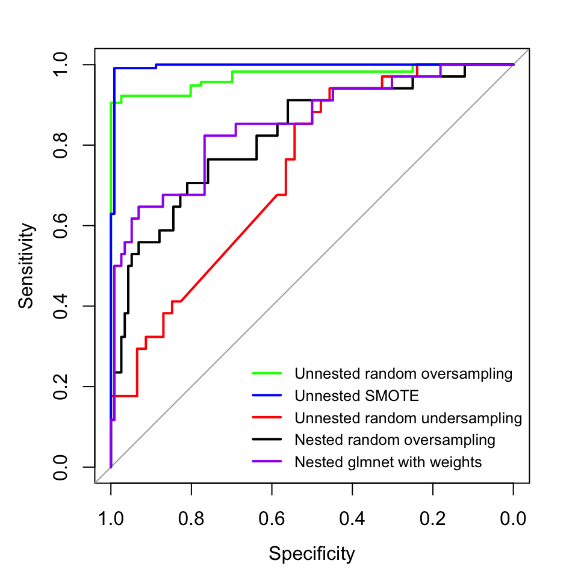

```r
plot(fit1$roc, col='green')
lines(fit1b$roc, col='red')
lines(fit2$roc, col='blue')
lines(fit3$roc)
lines(fit4$roc, col='purple')
legend('bottomright', legend = c("Unnested random oversampling",
                                 "Unnested SMOTE",
                                 "Unnested random undersampling",
                                 "Nested random oversampling",
                                 "Nested glmnet with weights"),
       col = c("green", "blue", "red", "black", "purple"), lty = 1, lwd = 2, bty = "n", cex=0.8)
```

This shows that unnested oversampling and unnested SMOTE leads to a data leak resulting in upward bias in apparent performance. The correct unbiased estimate of performance is ‘nested random oversampling’. Interestingly unnested random undersampling does not lead to any leakage of samples into left-out test folds, but the reduction in data size means that training is adversely affected and performance of the trained models is poor.

### Custom balancing function

A custom balancing function can be provided. The function must be of the form:

```r
balance <- function(y, x, ...) {

  return(list(y = y, x = x))
}
```

Other arguments can be passed in to the balance function as a named list via the `balance_options` argument. The function must return a list containing `y` an expanded/altered response vector and `x` the matrix or dataframe of predictors with increased/decreased samples in rows and predictors in columns.

# Nested CV with caret

Nested CV can also be performed using the `caret` package framework written by Max Kuhn (https://topepo.github.io/caret/index.html). This enables access to the large library of machine learning models available within caret.

Here we use `caret` for tuning the alpha and lambda parameters of `glmnet`.

```r
# nested CV using caret
tg <- expand.grid(lambda = exp(seq(log(2e-3), log(1e0), length.out = 100)),
                  alpha = seq(0.8, 1, 0.1))
ncv <- nestcv.train(y = yrtx, x = data.rtx,
               method = "glmnet",
               savePredictions = "final",
               filterFUN = ttest_filter, filter_options = list(nfilter = 300),
               tuneGrid = tg, cv.cores = 8)
ncv$summary

# Plot ROC on outer folds
plot(ncv$roc)

# Plot ROC on inner LO folds
inroc <- innercv_roc(ncv)
plot(inroc)
pROC::auc(inroc)

# Extract coefficients of final fitted model
glmnet_coefs(ncv$final_fit$finalModel, s = ncv$finalTune$lambda)
```

### Notes on caret

It is important to try calls to `nestcv.train` with `cv.cores=1` first. With `caret` this may flag up that specific packages are not installed or that there are problems with input variables `y` and `x` which may have to be corrected for the call to run in multicore mode. Once it is clear that the call to `nestcv.train` is working ok, you can quit single core execution and restart in multicore mode.

It is important to realise that the `train()` function in `caret` sets a parameter known as `tuneLength` to 3 by default, so the default tuning grid is minimal. `tuneLength` can easily be increased to give a tuning grid of greater granularity. Tuneable parameters for individual models can be inspected using `modelLookup()`, while `getModelInfo()` gives further information.

When fitting classification models, the usual default metric for tuning model hyperparameters in `caret` is Accuracy. However, with small datasets, accuracy is disproportionately affected by changes in a single individual’s prediction outcome from incorrect to correctly classified or vice versa. For this reason, we suggest using logLoss with smaller datasets as it provides more stable measures of model tuning behaviour. In `nestedcv`, when fitting classification models with `caret`, the default metric is changed to use logLoss.

We recommend that the results of tuning are plotted to understand whether parameters have a systematic effect on model accuracy. With small datasets tuning may pick parameters partially at random because of random fluctuations in measured accuracy during tuning, which may worsen noise surrounding performance than if they were fixed.

```r
# Example tuning plot for outer fold 1
plot(ncv$outer_result[[1]]$fit, xTrans = log)

# ggplot2 version
ggplot(ncv$outer_result[[1]]$fit) +
  scale_x_log10()
```

### Stratifying CV folds

By default `nestedcv` stratifies outer & inner CV folds based on the outcome variable using caret’s `createFolds()` function. Users can control CV folds directly by providing their own lists of fold indices. Outer CV fold indices can simply be provided via the argument `outer_folds` to `nestcv.glmnet()` or `nestcv.train()`. This is a list of vectors with one vector of indices used for each test CV fold.

The inner CV fold indices can also be controlled via the `inner_folds` argument. This is a list of a list of vectors. This can be useful if control of stratification is desired. The toy example below demonstrates how the `outer_folds` and `inner_folds` objects have to be structured.

```r
data(iris)
y <- iris$Species
x <- iris[, -5]

out_folds <- caret::createFolds(y, k = 8)
in_folds <- lapply(out_folds, function(i) {
  train_y <- y[-i]
  caret::createFolds(train_y, k = 8)
})

res <- nestcv.train(y, x, method = "rf",
                    cv.cores = 8,
                    inner_folds = in_folds,
                    outer_folds = out_folds)
summary(res)
res$outer_folds  # show which outer fold indices were used
```

In this example the outcome variable `y` has been used to stratify the folds for both outer and inner CV for 8 x 8 nested CV. But it could easily be replaced with a variable from the predictor dataframe if stratification by an imbalanced group is desired. For grouped data where members of a group must be kept together try using caret’s `groupKFold()` function. For stratification with multiple columns (e.g. response + one or more grouping variables), try `multi_strata()` from the `splitTools` package.

# Bayesian shrinkage models

See the accompanying vignette “Using *outercv* with Bayesian shrinkage models”.

# Extra performance metrics

For classification models, the function `metrics()` can be used to obtain additional performance metrics including area under precision-recall curve, Cohen’s kappa, F1 score and Matthews correlation coefficient. For binary classification, some of these vary depending on which category is considered the positive or relevant class. The default setting is that factors are ordered as ‘controls’ then ‘cases’ (factor level 1 then 2). Setting the argument `positive = 1` or to the character value of the positive factor level alters which factor level is considered positive or relevant. Cohen’s kappa, F1 macro score and Matthews correlation coefficient are also available for multi-class classification.

```r
library(mlbench)
data(Sonar)
y <- Sonar$Class
x <- Sonar[, -61]

fit1 <- nestcv.glmnet(y, x, family = "binomial", alphaSet = 1,
                      n_outer_folds = 4, cv.cores = 2)

metrics(fit1, extra = TRUE)
##               AUC          Accuracy Balanced accuracy            PR.AUC
##         0.8254853         0.7596154         0.7559209         0.7940713
##             Kappa                F1               MCC              nvar
##         0.5145178         0.7311828         0.5160771        17.0000000
```

## Precision-recall curves

While ROC curve objects are generated automatically for binary models, precision-recall curves can be quickly generated for `nestedcv` models using the convenience function `prc()` which employs the package ROCR.

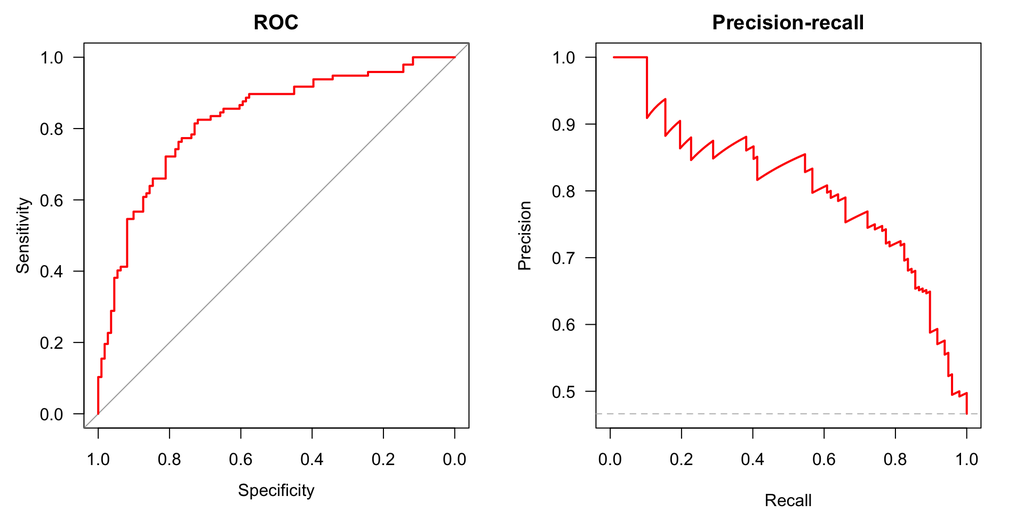

```r
fit1$prc <- prc(fit1)

# precision-recall AUC values
fit1$prc$auc
## [1] 0.7940713

# plot ROC and PR curves
op <- par(mfrow = c(1, 2), mar = c(4, 4, 2, 2) +.1)
plot(fit1$roc, col = "red", main = "ROC", las = 1)

plot(fit1$prc, col = "red", main = "Precision-recall")
```

```r
par(op)
```

# Making predictions

For all of the `nestedcv` model training functions described above, predictions on new data can be made by referencing the final fitted object which is fitted to the whole dataset.

```r
# for nestcv.glmnet object
preds <- predict(res.rtx, newdata = data.rtx, type = 'response')

# for nestcv.train object
preds <- predict(ncv, newdata = data.rtx)
```

# Repeated nested CV

The main commands `nestcv.glmnet()`, `nestcv.train()`, `nestcv.SuperLearner()` and `outercv()` perform nested CV once, giving an estimate of performance from the outer CV folds across the whole data. Repeating this process many times, which is called ‘repeated nested CV’, gives a more accurate overall estimate of performance. This can be performed by piping a call to one of the above `nestedcv` model functions to `repeatcv()` using the pipe `|>` (the standard magrittr pipe `%>%` will *not* work).

```r
data(Sonar)
y <- Sonar$Class
x <- Sonar[, -61]

# single fit
fit <- nestcv.glmnet(y, x, family = "binomial", alphaSet = 1,
                     n_outer_folds = 4, cv.cores = 2)

# repeated nested CV
set.seed(123, "L'Ecuyer-CMRG")
repcv <- nestcv.glmnet(y, x, family = "binomial", alphaSet = 1,
                       n_outer_folds = 4) |>
         repeatcv(8, rep.cores = 2)
```

```r
repcv
## Call:
## nestcv.glmnet(y, x, family = "binomial", alphaSet = 1, n_outer_folds = 4)
##
##      AUC Accuracy Balanced accuracy nvar
## 1 0.8205   0.7692            0.7675   20
## 2 0.8197   0.7452            0.7450   20
## 3 0.8210   0.7596            0.7592   20
## 4 0.8226   0.7885            0.7842   24
## 5 0.8129   0.7452            0.7450   18
## 6 0.8207   0.7500            0.7495   26
## 7 0.8264   0.7644            0.7624   22
## 8 0.8208   0.7308            0.7295   17
summary(repcv)
## Call:
## nestcv.glmnet(y, x, family = "binomial", alphaSet = 1, n_outer_folds = 4)
## 8 repeats
##                      mean       sd      sem
## AUC                0.8206 0.003731 0.001319
## Accuracy           0.7566 0.017793 0.006291
## Balanced accuracy  0.7553 0.016739 0.005918
## nvar              20.8750 2.997022 1.059607
```

If you are using repeated nested CV to compare performance between models, it is recommended to fix the sets of outer CV folds used across each repeat. The function `repeatfolds()` can be used to create a fixed set of outer CV folds for each repeat.

```r
folds <- repeatfolds(y, repeats = 3, n_outer_folds = 4)

repcv <- nestcv.glmnet(y, x, family = "binomial", alphaSet = 1,
                       n_outer_folds = 4) |>
         repeatcv(3, repeat_folds = folds, rep.cores = 2)
repcv
```

`repeatcv()` applied to binary `nestedcv` models will store a `pROC` object which concatenates all of the test fold predictions across all repeats. This can be easily plotted and shows a smoother ROC curve compared to the ROC curve from a single model.

Similarly, a more refined precision-recall curve can also be generated from the repeated nested CV predictions.

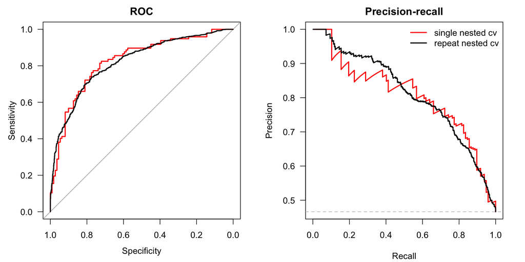

```r
op <- par(mfrow = c(1, 2), mar = c(4, 4, 2, 2) +.1)
plot(fit1$roc, col = "red", las = 1, main = "ROC")  # single nested cv
lines(repcv$roc)  # repeated nested cv

repcv$prc <- prc(repcv)  # calculate precision-recall curve

plot(fit1$prc, col = "red", main = "Precision-recall")  # single nested cv
lines(repcv$prc)  # repeated nested cv
legend("topright", legend = c("single nested cv", "repeat nested cv"),
       col = c("red", "black"), lwd = 2, bty = "n")
```

```r
par(op)
```

Repeated nested CV is computationally intensive and very time consuming. We strongly recommend that these calls fully exploit parallelisation as explained below.

# Parallelisation

Currently `nestcv.glmnet`, `nestcv.train`, `nestcv.SuperLearner` and `outercv` all allow parallelisation of the outer CV loop using `mclapply` from the `parallel` package on unix/mac and `parLapply` on windows. This is enabled by specifying the number of cores using the argument `cv.cores`. Since in some cases the filtering process can be time consuming (e.g. `rf_filter`, `relieff_filter`), we recommend parallelisation of the outermost loop, e.g. parallelisation of outer CV instead of inner CV tuning if you are using `nestcv.*`; or parallelisation of repeats if you are using `repeatcv`. Parallelisation is also possible using the `future` framework by setting the argument `parallel_mode = "future"` in `nestcv.*` functions or `rep_parallel` in `repeatcv`.

```r
# example parallelisation across outer CV
res <- nestcv.train(y, x, method = "gbm", cv.cores = 8)

# same using future
library(future)
# on linux/mac
plan(multicore, workers = 8)

# on windows or with Rstudio use
plan(multisession, workers = 8)

res <- nestcv.train(y, x, method = "gbm", parallel_mode = "future")

# parallelisation of repeat CV
res <- nestcv.train(y, x, method = "gbm") |>
    repeatcv(16, rep.cores = 8)

# same using future
res <- nestcv.train(y, x, method = "gbm") |>
    repeatcv(16, rep_parallel = "future")
```

To maintain consistency with random numbers during parallelisation set the random number seed in the following way:

```r
set.seed(123, "L'Ecuyer-CMRG")
```

The `caret` package is set up for parallelisation using `foreach` (https://topepo.github.io/caret/parallel-processing.html). We generally do not recommend nested parallelisation of both outer and inner loops, although this is theoretically feasible if you have enough cores. If *P* processors are registered with the parallel backend, some `caret` functionality leads to *P*<sup>2</sup> processes being generated. We generally find this does not lead to much speed up once the number of processes reaches the number of physical cores, as all processors are saturated and there is both time and memory overheads for duplicating data and packages for each process.

## How many cores?

Repeated nested CV is usually best parallelised over the repeats by maxing out `rep.cores` first, since there is less overhead due to fewer processes being spawned. You can set `cv.cores` as well, but beware this can lead to a large number of threads (the product of `rep.cores` x `cv.cores`).

`mclapply()` will not request more cores than the number of elements being parallelised. So if you set `n = 3` for 3 repeats, then there is no point setting `rep.cores` >= 4 as only 3 processes will be spawned across the repeats. Similarly if you do 10x10-fold nested CV, there is no point setting `cv.cores` >= 11 as only 10 processes can be spawned across the outer CV folds. So if you are doing low numbers of repeats (e.g. 3-5), then it may be slightly faster to set `cv.cores` to its maximum instead.

Parallelisation is generally fastest if the total number of cores requested is limited to the number of physical cores or just slightly above this, e.g. requesting a total of 8-10 cores on a CPU with 8 physical cores. To check the number of physical cores, use:

```r
parallel::detectCores(logical = FALSE)
```

# Troubleshooting

A key problem with parallelisation in R is that errors, warnings and user input have to be suppressed during multicore processing, except in Rstudio which allows some special printing to the console. If a `nestedcv` call is not working, we recommend that you try it with `cv.cores=1` first to check it starts up without error messages.

# Citation

If you use this package, please cite as:

Lewis MJ, Spiliopoulou A, Goldmann K, Pitzalis C, McKeigue P, Barnes MR (2023). nestedcv: an R package for fast implementation of nested cross-validation with embedded feature selection designed for transcriptomics and high dimensional data. *Bioinformatics Advances*. https://doi.org/10.1093/bioadv/vbad048

# References

Chawla, NV, Bowyer KW, Hall LO, Kegelmeyer WP. Smote: Synthetic minority over-sampling technique. *Journal of Artificial Intelligence Research* 2002; 16:321-357

Humby F, Durez P, Buch MH, Lewis MJ et al. Rituximab versus tocilizumab in anti-TNF inadequate responder patients with rheumatoid arthritis (R4RA): 16-week outcomes of a stratified, biopsy-driven, multicentre, open-label, phase 4 randomised controlled trial. *Lancet* 2021; 397(10271):305-317. https://doi.org/10.1016/s0140-6736(20)32341-2

Kuhn, M. Building Predictive Models in R Using the caret Package. *Journal of Statistical Software* 2008; 28(5):1-26.

Rivellese F, Surace AEA, Goldmann K, et al, Lewis MJ, Pitzalis C and the R4RA collaborative group. Rituximab versus tocilizumab in rheumatoid arthritis: Synovial biopsy-based biomarker analysis of the phase 4 R4RA randomized trial. *Nature medicine* 2022; 28(6):1256-1268. https://doi.org/10.1038/s41591-022-01789-0

Vabalas A, Gowen E, Poliakoff E, Casson AJ. Machine learning algorithm validation with a limited sample size. *PloS one* 2019;14(11):e0224365.

Zou, H, Hastie, T. Regularization and variable selection via the elastic net. *Journal of the Royal Statistical Society: Series B (Statistical Methodology)* 2005; 67(2): 301-320.